# exploration_slides slides

## Dataset Overview

This dataset features the Event data about users using the guide. Each column value except the UserId represents the number of times the user triggered the event.

For reference, this dataset includes the following events:

- `GuideDownload` which we record every time someone downloads a guide
- `GuideSession` which we record every time a user opens up a guide on their phone
- `ConnectionRequested` which we record every time a user sends a connection request to another user
- `PhotoUpload` which we record every time a guide user uploads a photo to a guide
- `UserId` users of the guide

### Gather Data

```python
df.head()
```

|  | index | GuideSession | GuideDownload | ConnectionRequested | PhotoUpload |
| --- | --- | --- | --- | --- | --- |
| 0 | 757 | 22.0 | 2.0 | NaN | NaN |
| 1 | 194 | 5.0 | 1.0 | 1.0 | 14.0 |
| 2 | 1656 | 32.0 | 1.0 | NaN | NaN |
| 3 | 563 | 11.0 | 1.0 | NaN | 2.0 |
| 4 | 1276 | 13.0 | 1.0 | NaN | NaN |

```python
df.describe()
```

|  | index | GuideSession | GuideDownload | ConnectionRequested | PhotoUpload |
| --- | --- | --- | --- | --- | --- |
| count | 2500.00000 | 2489.000000 | 2488.000000 | 510.000000 | 676.000000 |
| mean | 1249.50000 | 19.746083 | 1.446141 | 2.147059 | 7.423077 |
| std | 721.83216 | 10.535454 | 0.782494 | 1.632173 | 6.694940 |
| min | 0.00000 | 1.000000 | 1.000000 | 1.000000 | 1.000000 |
| 25% | 624.75000 | 13.000000 | 1.000000 | 1.000000 | 2.000000 |
| 50% | 1249.50000 | 19.000000 | 1.000000 | 2.000000 | 4.000000 |
| 75% | 1874.25000 | 24.000000 | 2.000000 | 3.000000 | 14.000000 |
| max | 2499.00000 | 161.000000 | 6.000000 | 11.000000 | 24.000000 |

#### Notes:

Our collected data has `2500 rows` and `5 columns`

Each column has missing data i.e:

- `GuideDownload` 12 records
- `GuideSession` 11 records
- `ConnectionRequested` 1990 records
- `PhotoUpload` 1824 records

The values in our interested columns are Float except the UserId column with integer values

### Exploration

For each analysis, one has to seek to answer certain questions about the data

Let's start our exploration by looking at users bucketed by number of times they triggered a `PhotoUpload` event. Is the distribution skewed or symmetric? Is it unimodal or multimodal?

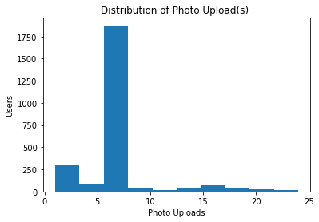

```python
# univariate plot of photos uploaded
plt.hist(data = df_master , x = 'PhotoUpload');
# plt.ylim(0,600)
plt.title('Distribution of Photo Upload(s) ')
plt.xlabel('Photo Uploads')
plt.ylabel('Users')
```

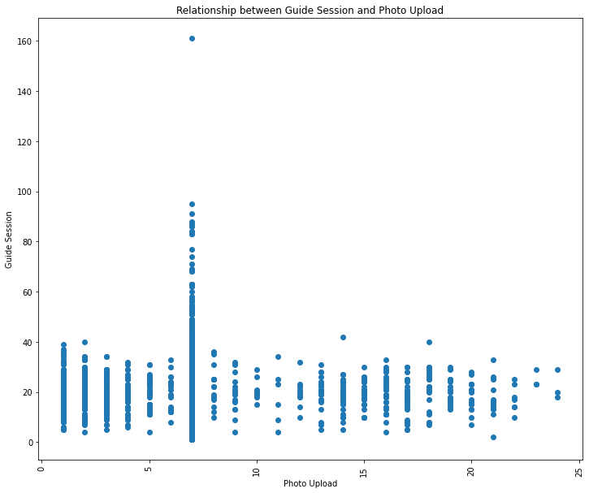

```python
# bivariate plot of photos uploaded vs. guide session
plt.figure(figsize = [12, 10])
base_color = sb.color_palette()[0]
plt.scatter(data = df_master , y = 'GuideSession' , x = 'PhotoUpload')
plt.title('Relationship between Guide Session and Photo Upload')
plt.xticks(rotation='vertical')
plt.ylabel('Guide Session')
plt.xlabel('Photo Upload')
```

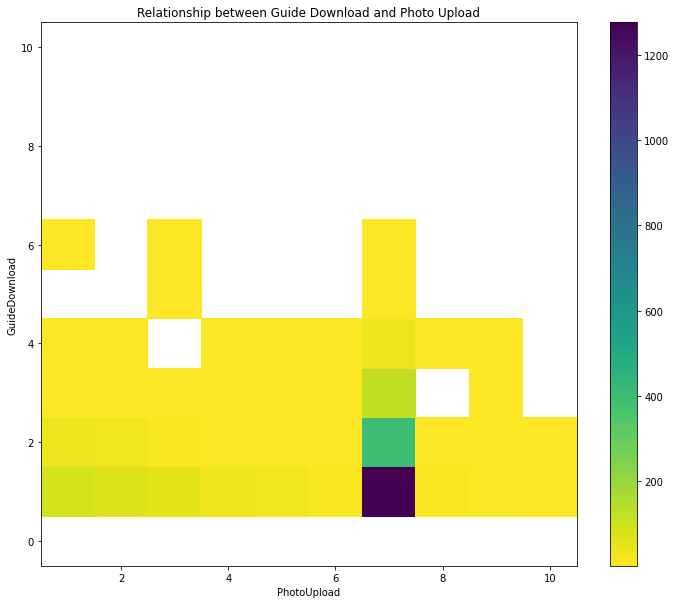

```python
plt.figure(figsize = [12, 10])
bins_x = np.arange(0.5, 10.5+1, 1)
bins_y = np.arange(-0.5, 10.5+1, 1)
plt.hist2d(data = df_master, y = 'GuideDownload', x = 'PhotoUpload',
           bins = [bins_x, bins_y], cmap = 'viridis_r', cmin = 0.5)
plt.colorbar()
plt.ylabel('GuideDownload')
plt.xlabel('PhotoUpload')
plt.title('Relationship between Guide Download and Photo Upload')
```